# musabi 情報形成デザイン5B

## DataFrame

Seriesはひと連なりの値(予算)とそのindex(映画のタイトル)の組み合わせを扱うことが出来ました。実際のデータを分析する場合、このようなSeriesの組み合わせが複数あることが良くあります。例えば

毎月の「温度」と「湿度」であったり、都道府県別の「人口」、「面積」、「世帯収入」など複数の種類の値を同じindexで まとめることができれば便利そうです。1月,2月,3月..12月と温度、湿度。もしくは東京,神奈川,...沖縄と人口、面積、世帯収入など複数の値を同じラベルで管理するイメージはエクセルの表をイメージするとわかりやすいかもしれません。

ここでは複数のSeriesをまとめて操作できる**DataFrame**について説明します。前回作った映画のタイトルと興行収入を、映画の予算のSeriesとまとめてDataFrameにしてみましょう。

```python
from pandas import DataFrame # DataFrameをインポート
```

まずSeriesを使う前と同じようにDataFrameもpandasから読み込みます

```python
movie = DataFrame()
movie['budget'] = [20, 28, 40, 11, 150, 108, 135, 13]
movie['boxoffice'] = [88, 133, 166, 62, 378, 630, 533, 36.2] # 興行収入
movie.index = ['スポットライト', 'マネー・ショート', 'ブリッジ・オブ・スパイ',
               'ブルックリン', 'マッドマックス', 'オデッセイ','レヴェナント','ルーム']
```

1行ずつ説明します。

```
movie = DataFrame()
```

1行目で空っぽのDataFrameオブジェクト(オブジェクトは便利なプログラミングするための形式くらいに思ってください。それ以上の知識はいまは必要ありません)をmovieという名前の変数にいれました。movieには空のDataFrameオブジェクトが入っています。

```
movie['budget'] = [20, 28, 40, 11, 150, 108, 135, 13]
movie['boxoffice'] = [88, 133, 166, 62, 378, 630, 533, 36.2]
```

つぎにmovieに'budget'という列をつくるイメージで考えてください。そこに予算のリストを入れました。おなじく'boxoffice'という列には、それぞれの興行収入のリストを入れています。

```
movie.index = ['スポットライト', 'マネー・ショート', 'ブリッジ・オブ・スパイ',
               'ブルックリン', 'マッドマックス', 'オデッセイ','レヴェナント','ルーム']
```

最後に映画のタイトルをindexにしました。この作業はSeriesにindexをつけたときと同じです。このmovieを確認してみます。

```python
movie
```

|  | budget | boxoffice |
| --- | --- | --- |
| スポットライト | 20 | 88.0 |
| マネー・ショート | 28 | 133.0 |
| ブリッジ・オブ・スパイ | 40 | 166.0 |
| ブルックリン | 11 | 62.0 |
| マッドマックス | 150 | 378.0 |
| オデッセイ | 108 | 630.0 |
| レヴェナント | 135 | 533.0 |
| ルーム | 13 | 36.2 |

このようにmovieというDataFrameにbudgetとboxofficeという列ができました。左の太文字の映画タイトルはindexをあらわします。

```python
movie.index # indexが映画タイトルであると確認
```

```
Index(['スポットライト', 'マネー・ショート', 'ブリッジ・オブ・スパイ', 'ブルックリン', 'マッドマックス', 'オデッセイ',
       'レヴェナント', 'ルーム'],
      dtype='object')
```

### DataFrameの操作

```python
movie['budget'] # Seriesが返ってくる
```

```
スポットライト         20
マネー・ショート        28
ブリッジ・オブ・スパイ     40
ブルックリン          11
マッドマックス        150
オデッセイ          108
レヴェナント         135
ルーム             13
Name: budget, dtype: int64
```

このようにSeriesで学んだことと同じように、予算のSeriesを得ることが出来ます。またすこし表記を変えて

```python
movie[['budget']] # DataFrameが返ってくる
```

|  | budget |
| --- | --- |
| スポットライト | 20 |
| マネー・ショート | 28 |
| ブリッジ・オブ・スパイ | 40 |
| ブルックリン | 11 |
| マッドマックス | 150 |
| オデッセイ | 108 |
| レヴェナント | 135 |
| ルーム | 13 |

こうすることでSeriesではなくDataFrameとして予算の値を得ることが出来ます。

```python
movie.loc['スポットライト'] # 予算と興行収入のSeriesが返ってくる
```

```
budget       20.0
boxoffice    88.0
Name: スポットライト, dtype: float64
```

indexを指定して予算と興行収入のSeriesが得られました。

```python
movie.loc[['スポットライト']] # データフレームとして予算と興行収入をえることもできます。
```

|  | budget | boxoffice |
| --- | --- | --- |
| スポットライト | 20 | 88.0 |

### DataFrame 条件を指定して取得

```python
movie[movie['budget'] > 100] # 予算が 100億円以上の映画のみに絞込み
```

|  | budget | boxoffice |
| --- | --- | --- |
| マッドマックス | 150 | 378.0 |
| オデッセイ | 108 | 630.0 |
| レヴェナント | 135 | 533.0 |

### DataFrame 一度に計算

Seriesと同様に各映画の新しい値を一度に計算することができます。ここでは売上を計算して新しくsalesという列に加えてみましょう。

```python
movie['sales'] = movie['boxoffice'] - movie['budget']
movie
```

|  | budget | boxoffice | sales |
| --- | --- | --- | --- |
| スポットライト | 20 | 88.0 | 68.0 |
| マネー・ショート | 28 | 133.0 | 105.0 |
| ブリッジ・オブ・スパイ | 40 | 166.0 | 126.0 |
| ブルックリン | 11 | 62.0 | 51.0 |
| マッドマックス | 150 | 378.0 | 228.0 |
| オデッセイ | 108 | 630.0 | 522.0 |
| レヴェナント | 135 | 533.0 | 398.0 |
| ルーム | 13 | 36.2 | 23.2 |

このようにDataFrameのなかの複数のSeriesを操作してあたらしいデータをつくることがよく行われます。ほかにも各映画の投資効率を示すROI (Return of Investment)を作ってみましょう。

```python
movie['roi'] = movie['boxoffice'] / movie['budget'] * 100 # パーセントであらわすため100掛ける
movie.sort_values(['roi'], ascending=False) # roi順に並べ替え
```

|  | budget | boxoffice | sales | roi |
| --- | --- | --- | --- | --- |
| オデッセイ | 108 | 630.0 | 522.0 | 583.333333 |
| ブルックリン | 11 | 62.0 | 51.0 | 563.636364 |
| マネー・ショート | 28 | 133.0 | 105.0 | 475.000000 |
| スポットライト | 20 | 88.0 | 68.0 | 440.000000 |
| ブリッジ・オブ・スパイ | 40 | 166.0 | 126.0 | 415.000000 |
| レヴェナント | 135 | 533.0 | 398.0 | 394.814815 |
| ルーム | 13 | 36.2 | 23.2 | 278.461538 |
| マッドマックス | 150 | 378.0 | 228.0 | 252.000000 |

興行収入も投資効率もオデッセイがもっと大きいということがわかります。これらの数値をひとつのグラフにまとめてみましょう。

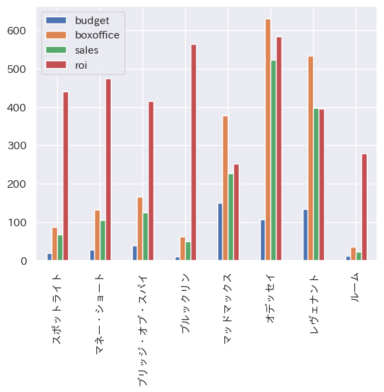

```python
movie.plot(kind='bar')
```

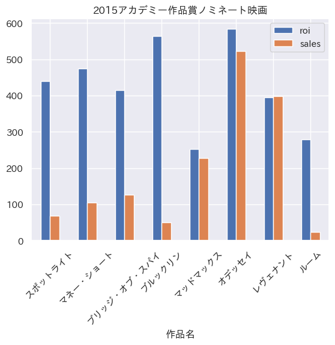

```python
ax = movie[['roi', 'sales']].plot(kind='bar', title='2015アカデミー作品賞ノミネート映画', rot=45)
ax.set_xlabel('作品名')
```

```python
### 映画データのまとめ
```

### DataFrame CSVファイルの読み込み

#### tokyo.csv

- 23区の男性人口・女性人口・総人口・世帯数・面積 2016年
- 出典ページ [住民基本台帳による東京都の世帯と人口 平成２８年１月](http://www.toukei.metro.tokyo.jp/juukiy/2016/jy16000001.htm)
- 出典データ jy16qa0100.xls
- CSVデータ tokyo.csv

#### tokyo_crime.csv

- 23区の犯罪認知件数 2015年
- 出典ページ [東京都の自治体別刑法犯発生状況（平成28年3月末【暫定値】・平成27年3月末【確定値】） リンク切れ](http://www.keishicho.metro.tokyo.jp/about_mpd/jokyo_tokei/jokyo/keiho.html)
- CSVデータ tokyo_crime.csv

```python
import pandas as pd # 今後pandasの様々な機能を使うためpdという名前をつけてpandasを読み込み
tokyo = pd.read_csv('csv/tokyo.csv', index_col=0) # csvの読み込み
tokyo
```

| name | female | male | setai | population | area |
| --- | --- | --- | --- | --- | --- |
| 千代田区 | 29321 | 29255 | 32871 | 58576 | 11.66 |
| 中央区 | 74828 | 68167 | 82057 | 142995 | 10.21 |
| 港区 | 128985 | 114992 | 138942 | 243977 | 20.37 |
| 新宿区 | 166430 | 167763 | 209872 | 334193 | 18.22 |
| 文京区 | 110185 | 100127 | 114459 | 210312 | 11.29 |
| 台東区 | 93339 | 98410 | 111848 | 191749 | 10.11 |
| 墨田区 | 131288 | 130435 | 141769 | 261723 | 13.77 |
| 江東区 | 252961 | 248540 | 254002 | 501501 | 40.16 |
| 品川区 | 192571 | 185552 | 209048 | 378123 | 22.84 |
| 目黒区 | 143287 | 128182 | 151257 | 271469 | 14.67 |
| 大田区 | 356381 | 355676 | 374463 | 712057 | 60.66 |
| 世田谷区 | 463103 | 420186 | 461518 | 883289 | 58.05 |
| 渋谷区 | 114347 | 105551 | 132932 | 219898 | 15.11 |
| 中野区 | 159398 | 162336 | 194834 | 321734 | 15.59 |
| 杉並区 | 287537 | 265751 | 309147 | 553288 | 34.06 |
| 豊島区 | 138871 | 141768 | 171610 | 280639 | 13.01 |
| 北区 | 171639 | 169613 | 186442 | 341252 | 20.61 |
| 荒川区 | 105856 | 105415 | 110853 | 211271 | 10.16 |
| 板橋区 | 278491 | 272267 | 292068 | 550758 | 32.22 |
| 練馬区 | 367109 | 352000 | 355564 | 719109 | 48.08 |
| 足立区 | 338301 | 340322 | 329506 | 678623 | 53.25 |
| 葛飾区 | 226068 | 226721 | 221587 | 452789 | 34.80 |
| 江戸川区 | 339582 | 346805 | 328681 | 686387 | 49.90 |

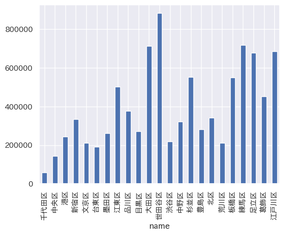

```python
tokyo['population'].plot(kind='bar')
```

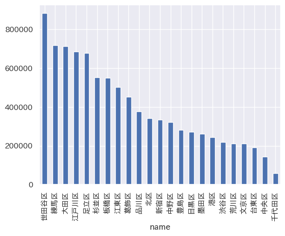

```python
tokyo['population'].sort_values(ascending=False).plot(kind='bar')
```

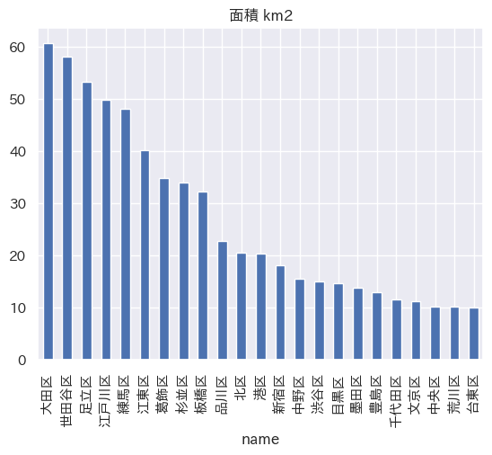

```python
tokyo['area'].sort_values(ascending=False).plot(kind='bar', title='面積 km2')
```

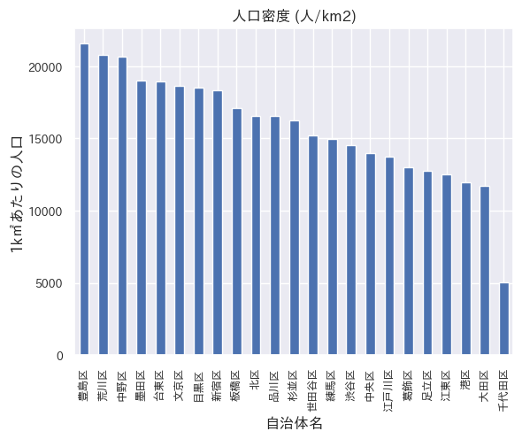

```python
tokyo['density'] = tokyo['population'] / tokyo['area']
ax = tokyo.density.sort_values(ascending=False).plot(kind='bar', fontsize=9, title='人口密度 (人/km2)')

ax.set_ylabel('1k㎡あたりの人口')
ax.set_xlabel('自治体名')
```

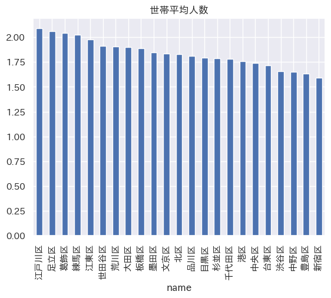

```python
tokyo['population_per_setai'] = tokyo['population'] / tokyo['setai']
tokyo.population_per_setai.sort_values(ascending=False).plot(kind='bar', title='世帯平均人数')
```

```python
tokyo_crime = pd.read_csv('csv/tokyo_crime.csv', index_col=0)
tokyo_crime
```

| name | crime |
| --- | --- |
| 千代田区 | 848.0 |
| 中央区 | 623.0 |
| 港区 | 1035.0 |
| 新宿区 | 1809.0 |
| 文京区 | 398.0 |
| 台東区 | 991.0 |
| 墨田区 | 804.0 |
| 江東区 | 1077.0 |
| 品川区 | 676.0 |
| 目黒区 | 498.0 |
| 大田区 | 1342.0 |
| 世田谷区 | 1580.0 |
| 渋谷区 | 1282.0 |
| 中野区 | 679.0 |
| 杉並区 | 917.0 |
| 豊島区 | 1157.0 |
| 北区 | 823.0 |
| 荒川区 | 448.0 |
| 板橋区 | 1404.0 |
| 練馬区 | 1346.0 |
| 足立区 | 1470.0 |
| 葛飾区 | 916.0 |
| 江戸川区 | 1657.0 |

```python
# tokyo.csvとtokyo_crime.csvの内容を index(=自治体名)で結合する
tokyo = tokyo.join(tokyo_crime)
tokyo
```

| name | female | male | setai | population | area | density | population_per_setai | crime |
| --- | --- | --- | --- | --- | --- | --- | --- | --- |
| 千代田区 | 29321 | 29255 | 32871 | 58576 | 11.66 | 5023.670669 | 1.781996 | 848.0 |
| 中央区 | 74828 | 68167 | 82057 | 142995 | 10.21 | 14005.386876 | 1.742630 | 623.0 |
| 港区 | 128985 | 114992 | 138942 | 243977 | 20.37 | 11977.270496 | 1.755963 | 1035.0 |
| 新宿区 | 166430 | 167763 | 209872 | 334193 | 18.22 | 18342.096597 | 1.592366 | 1809.0 |
| 文京区 | 110185 | 100127 | 114459 | 210312 | 11.29 | 18628.166519 | 1.837444 | 398.0 |
| 台東区 | 93339 | 98410 | 111848 | 191749 | 10.11 | 18966.271019 | 1.714371 | 991.0 |
| 墨田区 | 131288 | 130435 | 141769 | 261723 | 13.77 | 19006.753813 | 1.846123 | 804.0 |
| 江東区 | 252961 | 248540 | 254002 | 501501 | 40.16 | 12487.574701 | 1.974398 | 1077.0 |
| 品川区 | 192571 | 185552 | 209048 | 378123 | 22.84 | 16555.297723 | 1.808786 | 676.0 |
| 目黒区 | 143287 | 128182 | 151257 | 271469 | 14.67 | 18505.044308 | 1.794753 | 498.0 |
| 大田区 | 356381 | 355676 | 374463 | 712057 | 60.66 | 11738.493241 | 1.901542 | 1342.0 |
| 世田谷区 | 463103 | 420186 | 461518 | 883289 | 58.05 | 15216.003445 | 1.913878 | 1580.0 |
| 渋谷区 | 114347 | 105551 | 132932 | 219898 | 15.11 | 14553.143614 | 1.654214 | 1282.0 |
| 中野区 | 159398 | 162336 | 194834 | 321734 | 15.59 | 20637.203335 | 1.651324 | 679.0 |
| 杉並区 | 287537 | 265751 | 309147 | 553288 | 34.06 | 16244.509689 | 1.789725 | 917.0 |
| 豊島区 | 138871 | 141768 | 171610 | 280639 | 13.01 | 21571.022291 | 1.635330 | 1157.0 |
| 北区 | 171639 | 169613 | 186442 | 341252 | 20.61 | 16557.593401 | 1.830339 | 823.0 |
| 荒川区 | 105856 | 105415 | 110853 | 211271 | 10.16 | 20794.389764 | 1.905866 | 448.0 |
| 板橋区 | 278491 | 272267 | 292068 | 550758 | 32.22 | 17093.668529 | 1.885718 | 1404.0 |
| 練馬区 | 367109 | 352000 | 355564 | 719109 | 48.08 | 14956.509983 | 2.022446 | 1346.0 |
| 足立区 | 338301 | 340322 | 329506 | 678623 | 53.25 | 12744.093897 | 2.059516 | 1470.0 |
| 葛飾区 | 226068 | 226721 | 221587 | 452789 | 34.80 | 13011.178161 | 2.043392 | 916.0 |
| 江戸川区 | 339582 | 346805 | 328681 | 686387 | 49.90 | 13755.250501 | 2.088308 | 1657.0 |

```python
tokyo['crime'].sort_values(ascending=False)#.plot('bar', title='年間犯罪認知件数')
```

```
name
新宿区     1809.0
江戸川区    1657.0
世田谷区    1580.0
足立区     1470.0
板橋区     1404.0
練馬区     1346.0
大田区     1342.0
渋谷区     1282.0
豊島区     1157.0
江東区     1077.0
港区      1035.0
台東区      991.0
杉並区      917.0
葛飾区      916.0
千代田区     848.0
北区       823.0
墨田区      804.0
中野区      679.0
品川区      676.0
中央区      623.0
目黒区      498.0
荒川区      448.0
文京区      398.0
Name: crime, dtype: float64
```

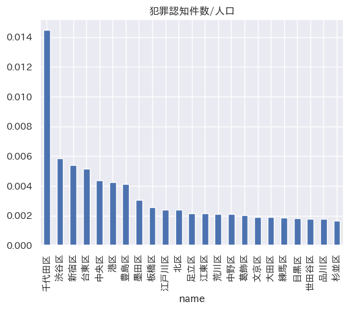

```python
(tokyo['crime'] / tokyo['population']).sort_values(ascending=False).plot(kind='bar', title='犯罪認知件数/人口')
```

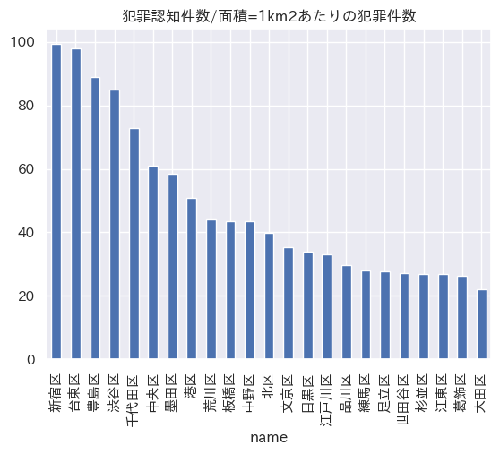

```python
(tokyo['crime'] / tokyo['area']).sort_values(ascending=False).plot(kind='bar', title='犯罪認知件数/面積=1km2あたりの犯罪件数')
```

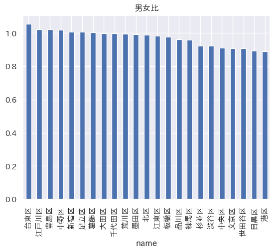

```python
fm = (tokyo['male'] / tokyo['female']).sort_values(ascending=False)
fm.plot(kind='bar', title='男女比')
```

### 時系列データを扱う

時間の流れが含まれている種類のデータを時系列データと言います。ここでは気象データをつかって時系列のデータの処理について紹介します。

- tokyo_rain.csv 東京の過去一年分の降水量

気象庁過去のデータ http://www.data.jma.go.jp/gmd/risk/obsdl/index.php

CSVデータ tokyo_rain.csv

```python
df = pd.read_csv('csv/tokyo_rain.csv')
df.head()
```

[output not shown]

```python
df = pd.read_csv('csv/tokyo_rain.csv', encoding='sjis') # エンコーディングを指定して文字化けを回避
df.head()
```

|  |  | ダウンロードした時刻：2016/06/24 22:22:07 |
| --- | --- | --- |
| NaN | 東京 | 東京 |
| 年月日時 | 降水量(mm) | 降水量(mm) |
| NaN | NaN | 現象なし情報 |
| 2015/1/1 1:00:00 | 0 | 1 |
| 2015/1/1 2:00:00 | 0 | 1 |

```python
df = pd.read_csv("csv/tokyo_rain.csv", encoding='sjis', skiprows=5) # 不要な先頭n行をスキップする
df.head()
```

|  | 2015/1/1 1:00:00 | 0 | 1 |
| --- | --- | --- | --- |
| 0 | 2015/1/1 2:00:00 | 0.0 | 1 |
| 1 | 2015/1/1 3:00:00 | 0.0 | 1 |
| 2 | 2015/1/1 4:00:00 | 0.0 | 1 |
| 3 | 2015/1/1 5:00:00 | 0.0 | 1 |
| 4 | 2015/1/1 6:00:00 | 0.0 | 1 |

```python
df = pd.read_csv("csv/tokyo_rain.csv",
                 encoding='sjis',
                 skiprows=5,
                 usecols=[0,1],
                 names=['date','rain'],
                 index_col=0) #使う列を指定し,列に名前を付ける
df.head()
```

| date | rain |
| --- | --- |
| 2015/1/1 1:00:00 | 0.0 |
| 2015/1/1 2:00:00 | 0.0 |
| 2015/1/1 3:00:00 | 0.0 |
| 2015/1/1 4:00:00 | 0.0 |
| 2015/1/1 5:00:00 | 0.0 |

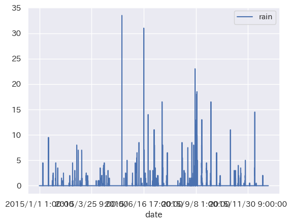

```python
df.plot(kind='line')
```

```python
df.index #dtype='object'となっていて見た目は日付だが、日付(datetime64)として認識されていない
```

```
Index(['2015/1/1 1:00:00', '2015/1/1 2:00:00', '2015/1/1 3:00:00',
       '2015/1/1 4:00:00', '2015/1/1 5:00:00', '2015/1/1 6:00:00',
       '2015/1/1 7:00:00', '2015/1/1 8:00:00', '2015/1/1 9:00:00',
       '2015/1/1 10:00:00',
       ...
       '2016/1/1 15:00:00', '2016/1/1 16:00:00', '2016/1/1 17:00:00',
       '2016/1/1 18:00:00', '2016/1/1 19:00:00', '2016/1/1 20:00:00',
       '2016/1/1 21:00:00', '2016/1/1 22:00:00', '2016/1/1 23:00:00',
       '2016/1/2 00:00:00'],
      dtype='object', name='date', length=8784)
```

```python
df = pd.read_csv('csv/tokyo_rain.csv',
                 encoding='sjis',  # エンコーディングをsjis指定
                 skiprows=5,       # 先頭5行を飛ばす
                 usecols=[0,1],    # 使う列は 0,1列
                 names=['date','rain'], #列に名前を付ける
                 index_col=0,      # indexは0列
                 parse_dates=True) #　日付を自動で変換する
df.head()

# 1 pd.read_csvでcsvを読み込む (indexの指定, 文字列の日付を日付型Datatime64に変換することに注意)
# 2 ヒートマップにしたい列を選ぶ 複数の列(雨と風など)を同時にヒートマップ化することはできない
# 3 すでについてある 月(month)と時間(hour)をつかって集計 (groupby) indexにはしない(as_index=False)
# 4 pivot で 月(month)か時間(hour)を90度回転 L字型にする
# 5 pivotしたデータフレームをsns.heatmapでビジュアライズ
```

| date | rain |
| --- | --- |
| 2015-01-01 01:00:00 | 0.0 |
| 2015-01-01 02:00:00 | 0.0 |
| 2015-01-01 03:00:00 | 0.0 |
| 2015-01-01 04:00:00 | 0.0 |
| 2015-01-01 05:00:00 | 0.0 |

```python
df.index #dtype='datetime64[ns]となっていることに注意
```

```
DatetimeIndex(['2015-01-01 01:00:00', '2015-01-01 02:00:00',
               '2015-01-01 03:00:00', '2015-01-01 04:00:00',
               '2015-01-01 05:00:00', '2015-01-01 06:00:00',
               '2015-01-01 07:00:00', '2015-01-01 08:00:00',
               '2015-01-01 09:00:00', '2015-01-01 10:00:00',
               ...
               '2016-01-01 15:00:00', '2016-01-01 16:00:00',
               '2016-01-01 17:00:00', '2016-01-01 18:00:00',
               '2016-01-01 19:00:00', '2016-01-01 20:00:00',
               '2016-01-01 21:00:00', '2016-01-01 22:00:00',
               '2016-01-01 23:00:00', '2016-01-02 00:00:00'],
              dtype='datetime64[ns]', name='date', length=8784, freq=None)
```

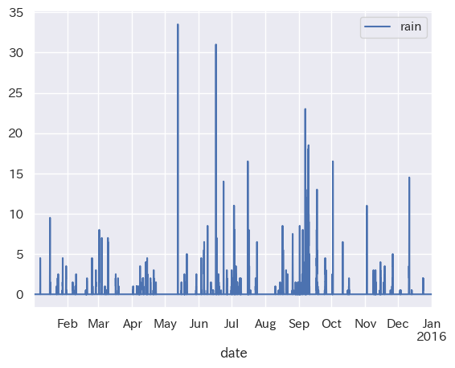

```python
df.plot()
```

```python
df.resample('1ME').sum() # 1ヶ月ごとの降水量の合計を出す
```

| date | rain |
| --- | --- |
| 2015-01-31 | 92.5 |
| 2015-02-28 | 62.0 |
| 2015-03-31 | 94.0 |
| 2015-04-30 | 129.0 |
| 2015-05-31 | 88.0 |
| 2015-06-30 | 195.0 |
| 2015-07-31 | 235.0 |
| 2015-08-31 | 103.0 |
| 2015-09-30 | 504.0 |
| 2015-10-31 | 57.0 |
| 2015-11-30 | 139.5 |
| 2015-12-31 | 82.5 |
| 2016-01-31 | 0.0 |

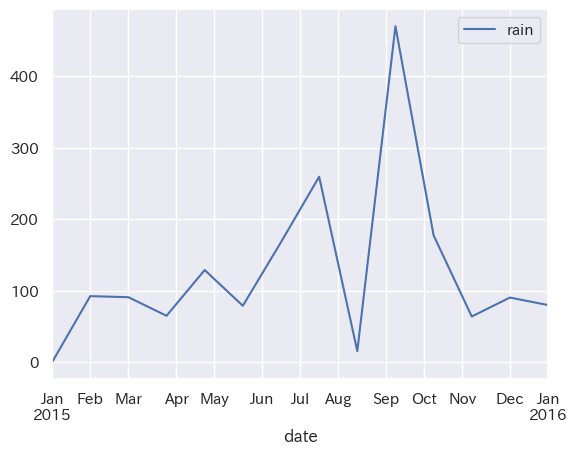

```python
df.resample('4W').sum().plot()
```

```python
df.resample('1ME').mean()#.plot()
```

| date | rain |
| --- | --- |
| 2015-01-31 | 0.124495 |
| 2015-02-28 | 0.092262 |
| 2015-03-31 | 0.126344 |
| 2015-04-30 | 0.179167 |
| 2015-05-31 | 0.118280 |
| 2015-06-30 | 0.270833 |
| 2015-07-31 | 0.315860 |
| 2015-08-31 | 0.138441 |
| 2015-09-30 | 0.700000 |
| 2015-10-31 | 0.076613 |
| 2015-11-30 | 0.193750 |
| 2015-12-31 | 0.110887 |
| 2016-01-31 | 0.000000 |

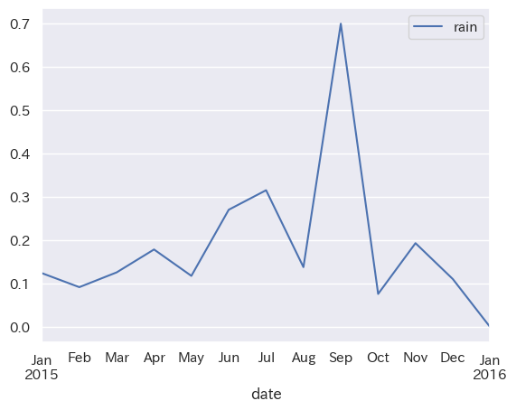

```python
df.resample('1ME').mean().plot()
```

```python
df.resample('2W').sum().head()
```

| date | rain |
| --- | --- |
| 2015-01-04 | 0.0 |
| 2015-01-18 | 42.0 |
| 2015-02-01 | 50.5 |
| 2015-02-15 | 16.5 |
| 2015-03-01 | 74.5 |

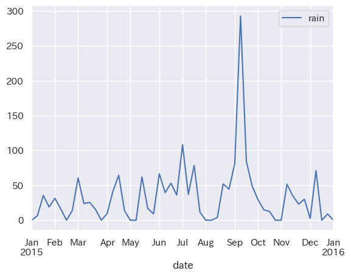

```python
df.resample('1W').sum().plot()
```

```python
df['weekday'] = df.index.day_name()
```

```python
df.sample(20)
```

| date | rain | weekday |
| --- | --- | --- |
| 2015-01-09 15:00:00 | 0.0 | Friday |
| 2015-05-25 09:00:00 | 0.0 | Monday |
| 2015-03-12 23:00:00 | 0.0 | Thursday |
| 2015-06-11 11:00:00 | 0.0 | Thursday |
| 2015-01-20 14:00:00 | 0.0 | Tuesday |
| 2015-12-09 08:00:00 | 0.0 | Wednesday |
| 2015-08-18 12:00:00 | 0.0 | Tuesday |
| 2015-05-07 13:00:00 | 0.0 | Thursday |
| 2015-05-07 03:00:00 | 0.0 | Thursday |
| 2015-11-27 03:00:00 | 0.0 | Friday |
| 2015-12-24 08:00:00 | 0.0 | Thursday |
| 2015-06-23 05:00:00 | 0.0 | Tuesday |
| 2015-05-26 04:00:00 | 0.0 | Tuesday |
| 2015-12-29 07:00:00 | 0.0 | Tuesday |
| 2015-07-24 23:00:00 | 0.0 | Friday |
| 2015-06-18 14:00:00 | 0.0 | Thursday |
| 2015-12-11 22:00:00 | 0.0 | Friday |
| 2015-10-02 21:00:00 | 0.0 | Friday |
| 2015-05-04 18:00:00 | 0.0 | Monday |
| 2015-03-17 16:00:00 | 0.0 | Tuesday |

```python
df.groupby('weekday').sum()
```

| weekday | rain |
| --- | --- |
| Friday | 346.5 |
| Monday | 217.5 |
| Saturday | 93.0 |
| Sunday | 153.5 |
| Thursday | 344.5 |
| Tuesday | 287.5 |
| Wednesday | 339.0 |

```python
df['hour'] = df.index.hour
df
```

| date | rain | weekday | hour |
| --- | --- | --- | --- |
| 2015-01-01 01:00:00 | 0.0 | Thursday | 1 |
| 2015-01-01 02:00:00 | 0.0 | Thursday | 2 |
| 2015-01-01 03:00:00 | 0.0 | Thursday | 3 |
| 2015-01-01 04:00:00 | 0.0 | Thursday | 4 |
| 2015-01-01 05:00:00 | 0.0 | Thursday | 5 |
| ... | ... | ... | ... |
| 2016-01-01 20:00:00 | 0.0 | Friday | 20 |
| 2016-01-01 21:00:00 | 0.0 | Friday | 21 |
| 2016-01-01 22:00:00 | 0.0 | Friday | 22 |
| 2016-01-01 23:00:00 | 0.0 | Friday | 23 |
| 2016-01-02 00:00:00 | 0.0 | Saturday | 0 |

8784 rows × 3 columns

```python
df.groupby('hour').sum()
```

| hour | rain | weekday |
| --- | --- | --- |
| 0 | 60.5 | FridaySaturdaySundayMondayTuesdayWednesdayThur... |
| 1 | 73.0 | ThursdayFridaySaturdaySundayMondayTuesdayWedne... |
| 2 | 53.0 | ThursdayFridaySaturdaySundayMondayTuesdayWedne... |
| 3 | 64.0 | ThursdayFridaySaturdaySundayMondayTuesdayWedne... |
| 4 | 87.0 | ThursdayFridaySaturdaySundayMondayTuesdayWedne... |
| 5 | 86.5 | ThursdayFridaySaturdaySundayMondayTuesdayWedne... |
| 6 | 98.0 | ThursdayFridaySaturdaySundayMondayTuesdayWedne... |
| 7 | 97.5 | ThursdayFridaySaturdaySundayMondayTuesdayWedne... |
| 8 | 81.0 | ThursdayFridaySaturdaySundayMondayTuesdayWedne... |
| 9 | 79.5 | ThursdayFridaySaturdaySundayMondayTuesdayWedne... |
| 10 | 77.0 | ThursdayFridaySaturdaySundayMondayTuesdayWedne... |
| 11 | 42.5 | ThursdayFridaySaturdaySundayMondayTuesdayWedne... |
| 12 | 53.5 | ThursdayFridaySaturdaySundayMondayTuesdayWedne... |
| 13 | 69.5 | ThursdayFridaySaturdaySundayMondayTuesdayWedne... |
| 14 | 60.0 | ThursdayFridaySaturdaySundayMondayTuesdayWedne... |
| 15 | 72.0 | ThursdayFridaySaturdaySundayMondayTuesdayWedne... |
| 16 | 78.5 | ThursdayFridaySaturdaySundayMondayTuesdayWedne... |
| 17 | 65.5 | ThursdayFridaySaturdaySundayMondayTuesdayWedne... |
| 18 | 59.5 | ThursdayFridaySaturdaySundayMondayTuesdayWedne... |
| 19 | 66.0 | ThursdayFridaySaturdaySundayMondayTuesdayWedne... |
| 20 | 59.0 | ThursdayFridaySaturdaySundayMondayTuesdayWedne... |
| 21 | 74.5 | ThursdayFridaySaturdaySundayMondayTuesdayWedne... |
| 22 | 106.5 | ThursdayFridaySaturdaySundayMondayTuesdayWedne... |
| 23 | 117.5 | ThursdayFridaySaturdaySundayMondayTuesdayWedne... |

```python
df_weekday = df.groupby(['weekday', 'hour'], as_index=False).sum()
df_weekday
```

|  | weekday | hour | rain |
| --- | --- | --- | --- |
| 0 | Friday | 0 | 9.0 |
| 1 | Friday | 1 | 17.0 |
| 2 | Friday | 2 | 7.5 |
| 3 | Friday | 3 | 11.5 |
| 4 | Friday | 4 | 8.0 |
| ... | ... | ... | ... |
| 163 | Wednesday | 19 | 8.5 |
| 164 | Wednesday | 20 | 15.5 |
| 165 | Wednesday | 21 | 9.5 |
| 166 | Wednesday | 22 | 25.5 |
| 167 | Wednesday | 23 | 8.0 |

168 rows × 3 columns

```python
pivot = df_weekday.pivot(index='weekday', columns='hour', values='rain')
pivot
```

| hour weekday | 0 | 1 | 2 | 3 | 4 | 5 | 6 | 7 | 8 | 9 | ... | 14 | 15 | 16 | 17 | 18 | 19 | 20 | 21 | 22 | 23 |
| --- | --- | --- | --- | --- | --- | --- | --- | --- | --- | --- | --- | --- | --- | --- | --- | --- | --- | --- | --- | --- | --- |
| Friday | 9.0 | 17.0 | 7.5 | 11.5 | 8.0 | 16.5 | 28.5 | 19.0 | 22.0 | 28.5 | ... | 2.5 | 18.0 | 3.5 | 7.5 | 8.0 | 11.5 | 15.0 | 12.0 | 16.0 | 20.5 |
| Monday | 11.5 | 11.0 | 1.0 | 6.5 | 8.0 | 5.5 | 7.0 | 11.0 | 14.5 | 10.5 | ... | 8.0 | 9.5 | 7.0 | 4.5 | 14.5 | 10.0 | 14.0 | 11.5 | 4.5 | 9.5 |
| Saturday | 16.0 | 11.0 | 7.0 | 11.0 | 9.0 | 2.5 | 5.5 | 3.5 | 1.5 | 1.5 | ... | 0.0 | 0.5 | 0.5 | 1.5 | 2.0 | 4.0 | 2.0 | 5.0 | 5.0 | 1.0 |
| Sunday | 1.0 | 3.0 | 2.5 | 3.0 | 3.5 | 7.0 | 8.5 | 8.5 | 6.5 | 4.0 | ... | 7.0 | 6.5 | 5.0 | 6.5 | 7.0 | 9.5 | 5.5 | 16.0 | 24.0 | 3.5 |
| Thursday | 8.5 | 11.0 | 19.0 | 14.5 | 33.5 | 33.5 | 19.5 | 22.0 | 14.5 | 12.0 | ... | 18.5 | 18.0 | 30.0 | 11.0 | 7.5 | 7.0 | 4.5 | 3.5 | 1.0 | 4.0 |
| Tuesday | 4.5 | 3.0 | 6.0 | 9.5 | 11.0 | 12.5 | 14.0 | 16.0 | 5.5 | 7.0 | ... | 2.5 | 4.5 | 13.5 | 14.0 | 7.0 | 15.5 | 2.5 | 17.0 | 30.5 | 71.0 |
| Wednesday | 10.0 | 17.0 | 10.0 | 8.0 | 14.0 | 9.0 | 15.0 | 17.5 | 16.5 | 16.0 | ... | 21.5 | 15.0 | 19.0 | 20.5 | 13.5 | 8.5 | 15.5 | 9.5 | 25.5 | 8.0 |

7 rows × 24 columns

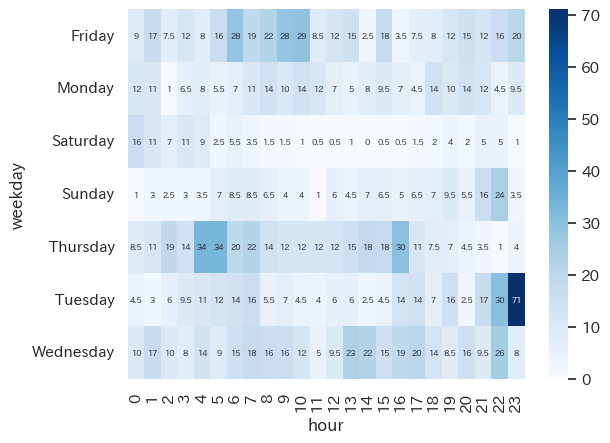

```python
seaborn.heatmap(pivot, annot=True, cmap='Blues', annot_kws={'size':6})
```

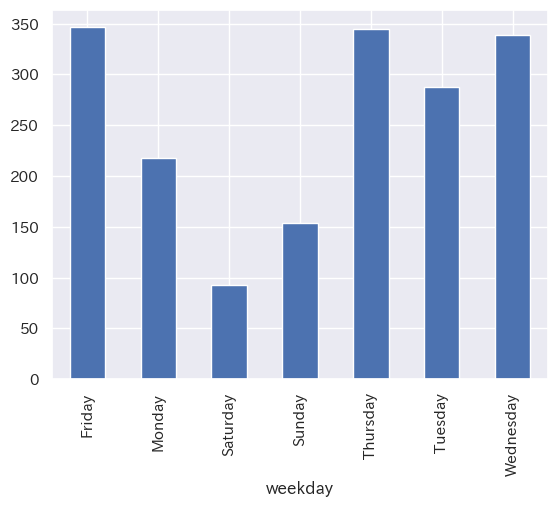

```python
df.groupby('weekday').sum()['rain'].plot(kind='bar')
```

```python
df.resample('1D').sum().describe() # 一日で155ミリ降っている日がある
```

|  | rain | hour |
| --- | --- | --- |
| count | 367.000000 | 367.000000 |
| mean | 4.854223 | 275.247956 |
| std | 13.571854 | 14.407083 |
| min | 0.000000 | 0.000000 |
| 25% | 0.000000 | 276.000000 |
| 50% | 0.000000 | 276.000000 |
| 75% | 3.000000 | 276.000000 |
| max | 155.500000 | 276.000000 |

```python
df_daily = df.resample('1D').sum()[['rain']]
df_daily.sort_values(by='rain', ascending=False)
```

| date | rain |
| --- | --- |
| 2015-09-09 | 155.5 |
| 2015-09-17 | 76.5 |
| 2015-12-11 | 66.5 |
| 2015-09-08 | 64.5 |
| 2015-07-03 | 59.5 |
| ... | ... |
| 2015-05-23 | 0.0 |
| 2015-05-22 | 0.0 |
| 2015-05-17 | 0.0 |
| 2015-05-15 | 0.0 |
| 2016-01-02 | 0.0 |

367 rows × 1 columns

[Wikipedia:平成27年9月関東・東北豪雨](https://goo.gl/j90EFb)

*9月7日に発生した台風18号は9月9日に東海地方へ上陸したのち、同日夜に日本海で温帯低気圧になった。この台風による直接的な被害は大きくなかったものの、日本海を北東に進む台風から変わった温帯低気圧に太平洋上から湿った暖かい空気が流れ込み、日本の東の海上から日本列島に接近していた台風17号から吹き込む湿った風とぶつかったことで南北に連なる雨雲（線状降水帯）が継続して発生[2][3]。関東地方北部から東北地方南部を中心として24時間雨量が300ミリ以上の豪雨とそれに伴う大規模な被害をもたらした。*

さらに大きなデータ9502件

1990-2016年東京降雨CSVデータ tokyo_rain_1990-2016.csv

```python
df = pd.read_csv("csv/tokyo_rain_1990-2016.csv",
                 encoding='sjis',  # エンコーディングをsjis指定
                 skiprows=5,       # 先頭5行を飛ばす
                 usecols=[0,1],    # 使う列は 0,1列
                 names=['date','rain'], #列に名前を付ける
                 index_col=0,      # indexは0列
                 parse_dates=True) #日付を自動で変換する
df.head()
df['weekday'] = df.index.day_name()
df.head()
```

| date | rain | weekday |
| --- | --- | --- |
| 1990-01-01 | 0.0 | Monday |
| 1990-01-02 | 0.0 | Tuesday |
| 1990-01-03 | 0.0 | Wednesday |
| 1990-01-04 | 0.0 | Thursday |
| 1990-01-05 | 0.0 | Friday |

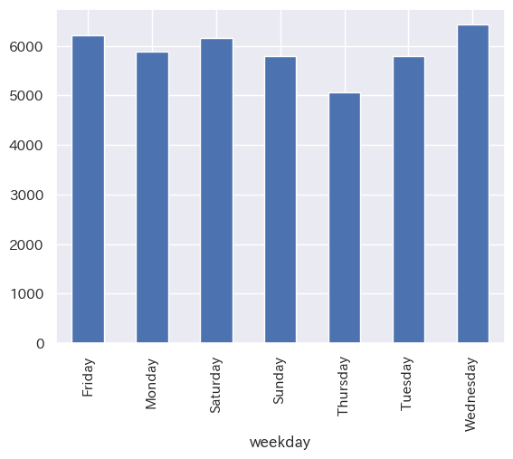

```python
df.groupby('weekday').sum()['rain'].plot(kind='bar')
```

## 課題

時系列のあるデータをダウンロードして resampleなどを活用してグラフにプロット

```python
flight = seaborn.load_dataset('flights') # 1949年から1960年までの旅客機利用者のデータをロード
flight.head(10)
```

|  | year | month | passengers |
| --- | --- | --- | --- |
| 0 | 1949 | Jan | 112 |
| 1 | 1949 | Feb | 118 |
| 2 | 1949 | Mar | 132 |
| 3 | 1949 | Apr | 129 |
| 4 | 1949 | May | 121 |
| 5 | 1949 | Jun | 135 |
| 6 | 1949 | Jul | 148 |
| 7 | 1949 | Aug | 148 |
| 8 | 1949 | Sep | 136 |
| 9 | 1949 | Oct | 119 |

```python
flight.pivot(index='month', columns='year', values='passengers')
```

| year month | 1949 | 1950 | 1951 | 1952 | 1953 | 1954 | 1955 | 1956 | 1957 | 1958 | 1959 | 1960 |
| --- | --- | --- | --- | --- | --- | --- | --- | --- | --- | --- | --- | --- |
| Jan | 112 | 115 | 145 | 171 | 196 | 204 | 242 | 284 | 315 | 340 | 360 | 417 |
| Feb | 118 | 126 | 150 | 180 | 196 | 188 | 233 | 277 | 301 | 318 | 342 | 391 |
| Mar | 132 | 141 | 178 | 193 | 236 | 235 | 267 | 317 | 356 | 362 | 406 | 419 |
| Apr | 129 | 135 | 163 | 181 | 235 | 227 | 269 | 313 | 348 | 348 | 396 | 461 |
| May | 121 | 125 | 172 | 183 | 229 | 234 | 270 | 318 | 355 | 363 | 420 | 472 |
| Jun | 135 | 149 | 178 | 218 | 243 | 264 | 315 | 374 | 422 | 435 | 472 | 535 |
| Jul | 148 | 170 | 199 | 230 | 264 | 302 | 364 | 413 | 465 | 491 | 548 | 622 |
| Aug | 148 | 170 | 199 | 242 | 272 | 293 | 347 | 405 | 467 | 505 | 559 | 606 |
| Sep | 136 | 158 | 184 | 209 | 237 | 259 | 312 | 355 | 404 | 404 | 463 | 508 |
| Oct | 119 | 133 | 162 | 191 | 211 | 229 | 274 | 306 | 347 | 359 | 407 | 461 |
| Nov | 104 | 114 | 146 | 172 | 180 | 203 | 237 | 271 | 305 | 310 | 362 | 390 |
| Dec | 118 | 140 | 166 | 194 | 201 | 229 | 278 | 306 | 336 | 337 | 405 | 432 |

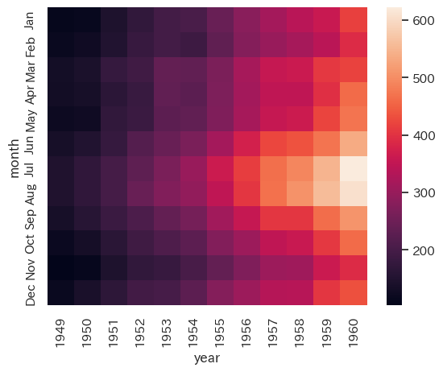

```python
pivot = flight.pivot(index='month', columns='year', values='passengers')
seaborn.heatmap(pivot)
```

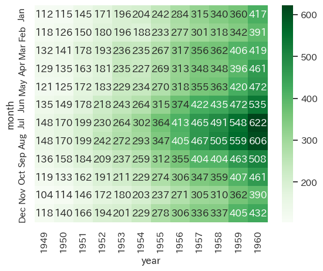

```python
seaborn.heatmap(pivot, annot=True, fmt='g', cmap='Greens')
```

```python
df = pd.read_csv('csv/yamaguchi2015_hourly_weather.csv',
                index_col=0,
                parse_dates=True)
df.describe()
```

|  | wind | rain | temp | sun | hpa | hour | month |
| --- | --- | --- | --- | --- | --- | --- | --- |
| count | 8784.000000 | 8776.000000 | 8784.000000 | 8783.000000 | 8784.000000 | 8784.000000 | 8784.000000 |
| mean | 1.874841 | 0.234788 | 15.902379 | 0.211898 | 1013.336669 | 11.500000 | 6.535633 |
| std | 1.350278 | 1.235029 | 8.451104 | 0.367457 | 7.388519 | 6.922581 | 3.448237 |
| min | 0.000000 | 0.000000 | -3.400000 | 0.000000 | 977.900000 | 0.000000 | 1.000000 |
| 25% | 0.900000 | 0.000000 | 8.900000 | 0.000000 | 1008.000000 | 5.750000 | 4.000000 |
| 50% | 1.500000 | 0.000000 | 16.600000 | 0.000000 | 1013.000000 | 11.500000 | 7.000000 |
| 75% | 2.500000 | 0.000000 | 22.700000 | 0.300000 | 1018.700000 | 17.250000 | 10.000000 |
| max | 13.300000 | 27.500000 | 36.700000 | 1.000000 | 1033.800000 | 23.000000 | 12.000000 |

```python
df.head()
```

| date | wind | windir | rain | temp | sun | hpa | hour | month |
| --- | --- | --- | --- | --- | --- | --- | --- | --- |
| 2015-01-01 01:00:00 | 2.8 | 西 | 0.0 | 4.1 | 0.0 | 1012.5 | 1 | 1 |
| 2015-01-01 02:00:00 | 2.9 | 西 | 0.0 | 3.9 | 0.0 | 1012.9 | 2 | 1 |
| 2015-01-01 03:00:00 | 4.4 | 西北西 | 0.0 | 3.4 | 0.0 | 1012.8 | 3 | 1 |
| 2015-01-01 04:00:00 | 4.0 | 北西 | 0.0 | 3.2 | 0.0 | 1013.1 | 4 | 1 |
| 2015-01-01 05:00:00 | 5.6 | 西北西 | 0.0 | 2.3 | 0.0 | 1013.2 | 5 | 1 |

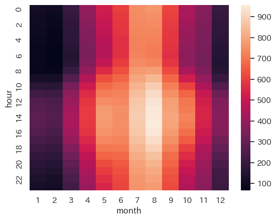

```python
df = df.groupby(['month','hour'], as_index=False).sum()
pivot = df.pivot(index='hour', columns='month', values='temp')
seaborn.heatmap(pivot)
```

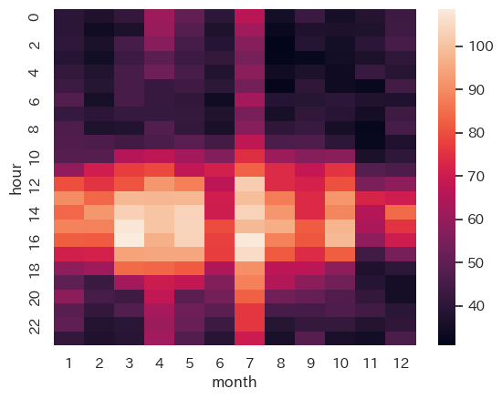

```python
pivot = df.pivot(index='hour', columns='month', values='wind')
seaborn.heatmap(pivot)
```

## 課題

- データをオンラインまたは身の回りから探してくる (オンライン, 自宅の電力消費, Apple Watch etc..)
- A4程度の紙に縦軸(index)、横軸(colums)、値(values)をできるだけ正確に定義してスケッチを書いてみる (特に値を複数実際に書きこむこと)
- データをPandasで加工しSeabornでheatmapを作成する

## 発表(最終日)

- スケッチの紹介
- 最終的なヒートマップとそのNotebookの紹介

## 評価基準

- Pandasでのデータの解析、フィルタリング、表現
- 取り組むデータへ理解
- 自律的な問題解決の姿勢
- 積極的なオンライン授業への参加(質疑、周りの参加者とのコミュニケーションなど)